# Generating and Presenting Data

Kirin Patel

2/3/2020

## Importing Libraries

```r
library(ggplot2)
require(plyr)
```

## Choosing a dataset

For this assignment, we have been tasked with choosing a dataset from [OpenFloodAI’s Climate Change Dataset](https://github.com/OpenFloodAI/Climate-Change-Datasets).

I chose the [CO2 PPM - Trends in Atmospheric Carbon Dioxide](https://datahub.io/core/co2-ppm) dataset that is provided by the US government.

## Loading the data

```r
# Load data
data_url = "https://datahub.io/core/co2-ppm/r/co2-mm-mlo.csv"
ppm = read.csv(url(data_url))

head(ppm)
```

```
##         Date Decimal.Date Average Interpolated  Trend Number.of.Days
## 1 1958-03-01     1958.208  315.71       315.71 314.62             -1
## 2 1958-04-01     1958.292  317.45       317.45 315.29             -1
## 3 1958-05-01     1958.375  317.50       317.50 314.71             -1
## 4 1958-06-01     1958.458  -99.99       317.10 314.85             -1
## 5 1958-07-01     1958.542  315.86       315.86 314.98             -1
## 6 1958-08-01     1958.625  314.93       314.93 315.94             -1
```

```r
# Map values of date header
ppm$'Date' <- as.numeric(substr(ppm$'Date',1,4))
```

## Viewing the data

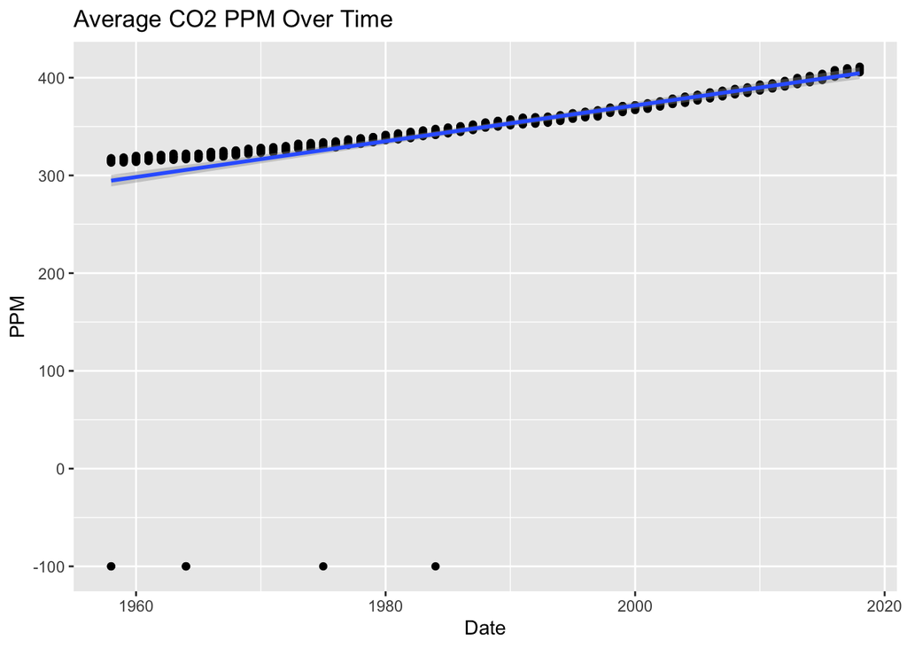

```r
ggplot(data=ppm,aes(x=ppm$'Date',y=as.numeric(ppm$'Average'))) +
  geom_point() +
  geom_smooth(method='lm') +
  xlab('Date') +
  ylab('PPM') +
  ggtitle('Average CO2 PPM Over Time')
```

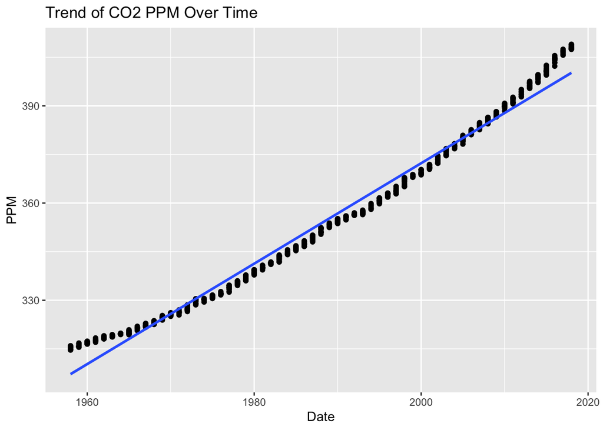

```r
ggplot(data=ppm,aes(x=ppm$'Date',y=as.numeric(ppm$'Trend'))) +
  geom_point() +
  geom_smooth(method='lm') +
  xlab('Date') +
  ylab('PPM') +
  ggtitle('Trend of CO2 PPM Over Time')
```

When looking at both the average and overall trend of CO2 PPM over time, both the average and trend of CO2 PPM are increasing.

## Loading additional data

```r
data_url = "https://pkgstore.datahub.io/core/global-temp/annual_csv/data/a26b154688b061cdd04f1df36e4408be/annual_csv.csv"
temperature = read.csv(url(data_url))
```

## Viewing temperature data

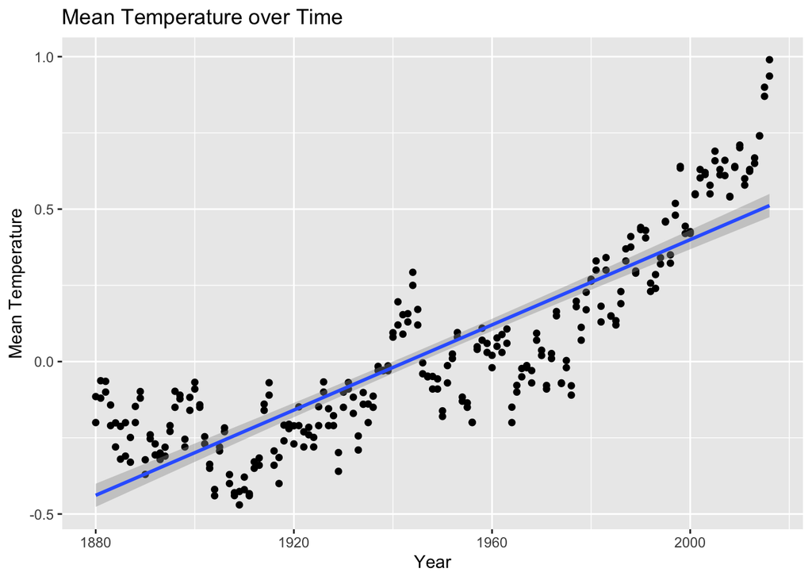

```r
ggplot(data=temperature,aes(x=temperature$'Year',y=temperature$'Mean')) +
  geom_point() +
  geom_smooth(method='lm') +
  xlab('Year') +
  ylab('Mean Temperature') +
  ggtitle('Mean Temperature over Time')
```

## Investigating both Datasets

When combining the data from the first and second datasets, it is evident that both the average CO2 PPM and mean temperature has increased over time. Furthermore it can be deduced that the increase in average CO2 PPM is a direct cause for the increase in mean temperature over time (Climate Change: Atmospheric Carbon Dioxide: NOAA Climate.gov, 2019). This is because “Carbon dioxide is a greenhouse gas: a gas that absorbs heat” (Climate Change: Atmospheric Carbon Dioxide: NOAA Climate.gov, 2019). Due to the continually growth of CO2 within our atmosphere and its heat absorbing attributes, the mean temperature is guaranteed to increase since more heat can be absored due to the increase of CO2.

## Citations

Climate Change: Atmospheric Carbon Dioxide: NOAA Climate.gov. (2019, September 19). Retrieved from https://www.climate.gov/news-features/understanding-climate/climate-change-atmospheric-carbon-dioxide